# Time Series Analysis

David Faria

18 octobre 2016

Taken from (https://www.analyticsvidhya.com/blog/2015/12/complete-tutorial-time-series-modeling/)

## Importing data

```r
data("AirPassengers")

class(AirPassengers)
```

```
## [1] "ts"
```

This is the start of the time series

```r
start(AirPassengers)
```

```
## [1] 1949    1
```

This is the end of the time series

```r
end(AirPassengers)
```

```
## [1] 1960   12
```

The cycle of this time series is 12months in a year

```r
frequency(AirPassengers)
```

```
## [1] 12
```

The number of passengers are distributed across the spectrum

```r
summary(AirPassengers)
```

```
##    Min. 1st Qu.  Median    Mean 3rd Qu.    Max.
##   104.0   180.0   265.5   280.3   360.5   622.0
```

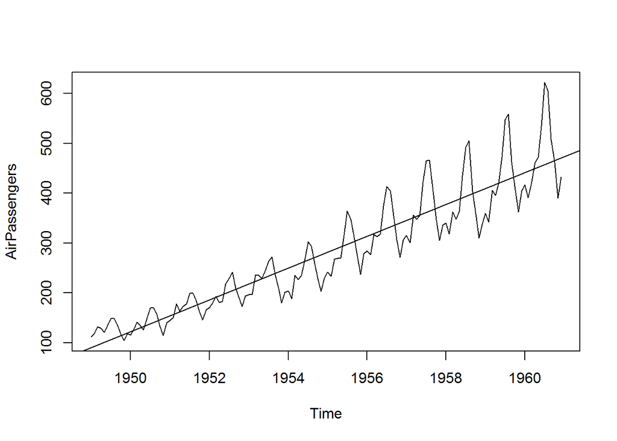

```r
plot(AirPassengers)
abline(reg=lm(AirPassengers~time(AirPassengers)))
```

This will print the cycle across years.

```r
cycle(AirPassengers)
```

```
##      Jan Feb Mar Apr May Jun Jul Aug Sep Oct Nov Dec
## 1949   1   2   3   4   5   6   7   8   9  10  11  12
## 1950   1   2   3   4   5   6   7   8   9  10  11  12
## 1951   1   2   3   4   5   6   7   8   9  10  11  12
## 1952   1   2   3   4   5   6   7   8   9  10  11  12
## 1953   1   2   3   4   5   6   7   8   9  10  11  12
## 1954   1   2   3   4   5   6   7   8   9  10  11  12
## 1955   1   2   3   4   5   6   7   8   9  10  11  12
## 1956   1   2   3   4   5   6   7   8   9  10  11  12
## 1957   1   2   3   4   5   6   7   8   9  10  11  12
## 1958   1   2   3   4   5   6   7   8   9  10  11  12
## 1959   1   2   3   4   5   6   7   8   9  10  11  12
## 1960   1   2   3   4   5   6   7   8   9  10  11  12
```

This will aggregate the cycles and display a year on year trend

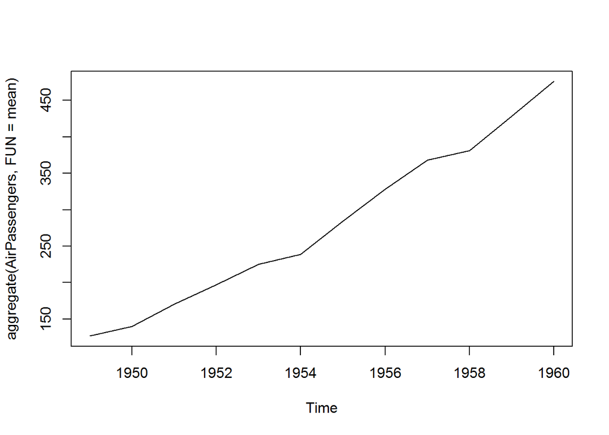

```r
plot(aggregate(AirPassengers,FUN=mean))
```

Box plot across months will give us a sense on seasonal effect

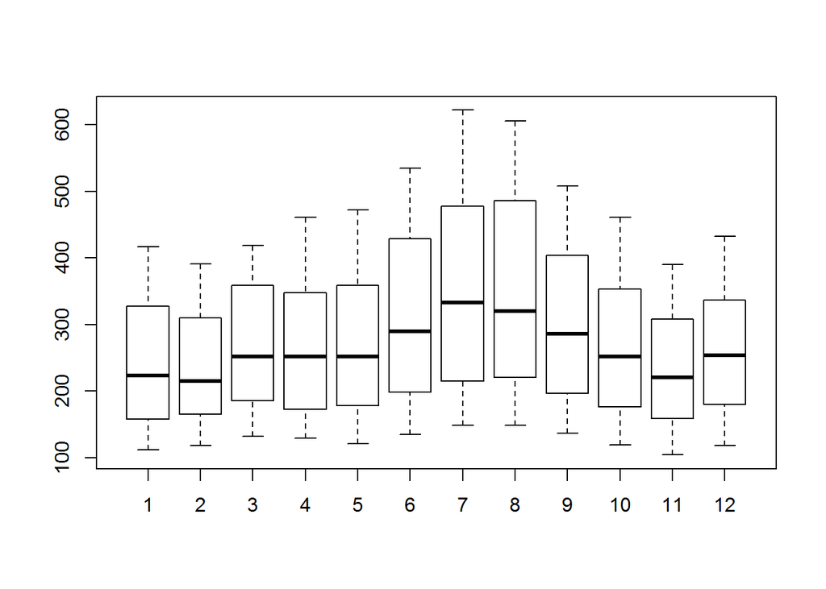

```r
boxplot(AirPassengers~cycle(AirPassengers))
```

## Important Inferences

- The year on year trend clearly shows that the #passengers have been increasing without fail.
- The variance and the mean value in July and August is much higher than rest of the months.
- Even though the mean value of each month is quite different their variance is small. Hence, we have strong seasonal effect with a cycle of 12 months or less.

# ARMA Time Series Modeling

- AR stands for auto-regression
- MA stands for moving average

AR or MA are not applicable on non-stationary series.

## AR

$x(t) = alpha * x(t - 1) + error (t)$

This equation is known as AR(1) formulation. The numeral one (1) denotes that the next instance is solely dependent on the previous instance. The alpha is a coefficient which we seek so as to minimize the error function. Notice that x(t- 1) is indeed linked to x(t-2) in the same fashion. Hence, any shock to x(t) will gradually fade off in future.

## MA

$x(t) = beta * error(t-1) + error (t)$

In MA model, noise / shock quickly vanishes with time. The AR model has a much lasting effect of the shock.

# Identifying AR/MA: Total Correlation Charts

Also known as Auto - correlation Function / ACF, is a plot of total correlation between different lag functions

- In a MA series of lag n, we will not get any correlation between x(t) and x(t - n -1). Hence, the total correlation chart cuts off at nth lag. So it becomes simple to find the lag for a MA series.
- For an AR series this correlation will gradually go down without any cut off value. If we find out the partial correlation of each lag (PACF), it will cut off after the degree of AR series. For instance,if we have a AR(1) series, if we exclude the effect of 1st lag (x (t-1) ), our 2nd lag (x (t-2) ) is independent of x(t). Hence, the partial correlation function (PACF) will drop sharply after the 1st lag.

# Time series Framework

### 1. Detrending :

Here, we simply remove the trend component from the time series. For instance, the equation of my time series is:

$x(t) = (mean + trend * t) + error$

We’ll simply remove the part in the parentheses and build model for the rest.

### 2. Differencing :

This is the commonly used technique to remove non-stationarity. Here we try to model the differences of the terms and not the actual term. For instance,

$x(t) - x(t-1) = ARMA (p , q)$

This differencing is called as the Integration part in AR(I)MA. Now, we have three parameters

$p : AR$

$d : I$

$q : MA$

## 3. Plot ACF/PACF charts and fin optimar parameters

## 4. Build the ARIMA model

## 5. Make Predictions